# MicroarrayPilot

2022-09-28

# Background and Introduction

Microarray expression profiling is one of several genetic approaches that provides insight into our molecular and systems understanding of development and functioning. The basic concept is that there are probes on a microarray plate that correspond with a specific genes of the organism. When the tissue is placed on the microarray after treatment there is hybridization between the probe and the gene. After scanning the microarray, one would get a file with the different affinities of bininding for each probeset.

This is a smaller pilot data set that was run before the experiment there are TWO time points T-18 and T-24 There are Four strains: LPR, LPR2, PLUS and WT (WildType).

Main question: -Compare MRL/MPJ domain with WT across the weeks. -MRL/MPJ (LPR,LPR2,PLUS) is the Lupus disease model

Once you have performed the quality control check, you can proceed to normalize the data. Normalization is a necessary step because it ensures that the data is on the same scale, which is important for accurate comparison and analysis.

After normalizing the data, you can perform statistical analysis to identify any patterns or trends in the data. This can include identifying differentially expressed genes, clustering genes based on expression levels, and performing hypothesis testing to determine the significance of any observed patterns.

Once you have identified any patterns or trends in the data, you can interpret the results in the context of the biological system or question that you are studying. This may involve consulting relevant literature and discussing the results with other researchers in the field.

We use Robust Multiarray Average (rma) to normalize the data: -The calculation behind RMA involves first log-transforming the raw intensity values for each probe on each array. Next, the median log-intensity value is calculated for each probe across all arrays. This median value is then used to correct the log-intensity values for each probe on each array, by subtracting the median value from the log-intensity value for each probe.

-After correcting for systematic biases, the data is then quantile-normalized to ensure that the data is on the same scale. This is done by ranking the log-intensity values for each probe on each array and then using a quantile-based method to adjust the values so that they have the same distribution across all arrays.

## Reference

These resources have been used as inspiration to create a suitable pipeline for the micro array data analysis.

https://wiki.bits.vib.be/index.php/Analyze_your_own_microarray_data_in_R/Bioconductor https://bioconductor.org/packages/release/workflows/vignettes/maEndToEnd/inst/doc/MA-Workflow.html#13_Gene_ontology_(GO)_based_enrichment_analysis https://bioconductor.org/packages/release/bioc/vignettes/topGO/inst/doc/topGO.pdf https://bioconductor.org/packages/release/bioc/manuals/ReactomePA/man/ReactomePA.pdf

#T24 Due to the differences in the number of samples available for each group across T18-24. We would need to do separate the analysis based on the time. -There are only LPR and WT saples for T-18

## load the data .cel files

```r
# Set the path to the directory containing the CEL files for T-24
celpathT24 <- "/Users/brookt/R projects/LupusProject/2022 Analysis_MRL v C57/T-24"

# Read the targets file for T-24
targets24 <- readTargets("targetsT24.txt")

# Create a list of the CEL files in the T-24 directory
celFiles <- list.celfiles(celpathT24, full.name = TRUE)

# Read the CEL files and create a raw data object
rawData <- ReadAffy(verbose = FALSE, filenames = celFiles)
# Normalize the data using RMA
data.rma.norm <- affy::rma(rawData)
```

```
## Background correcting
## Normalizing
## Calculating Expression
```

```r
# Set the column names of the normalized data to the sample names from the targets file
colnames(data.rma.norm) <- row.names(targets24)
```

## Creating Proble Level Images

You can create a probelevel image of the Microarray, if you are looking for specific patterns, EG: if you split a plate for samples It is commented out since we are not interested in it

## Quick visualizations

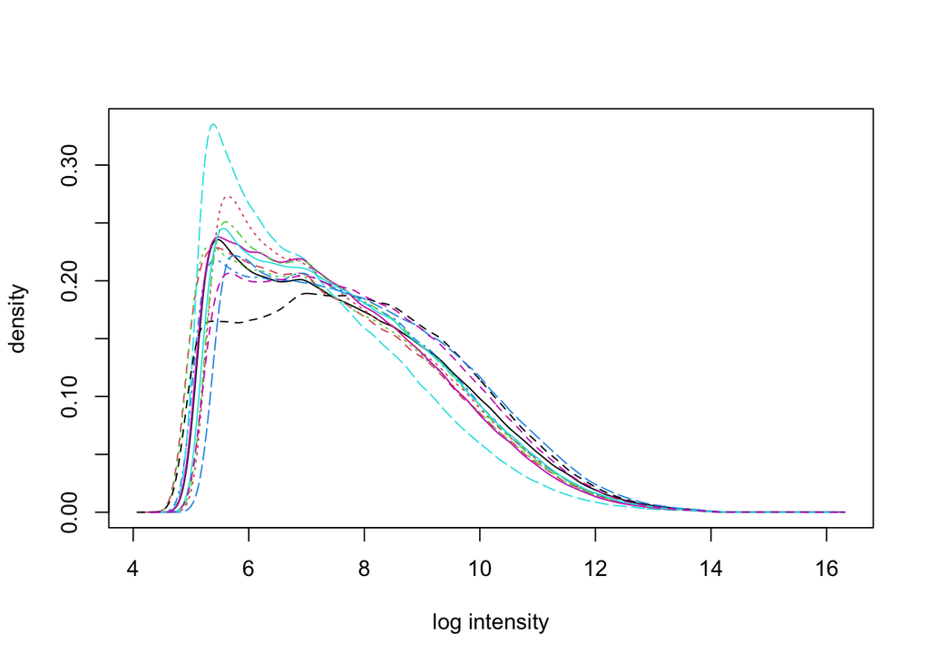

```r
hist(rawData) # quick hist summary of log_difference
```

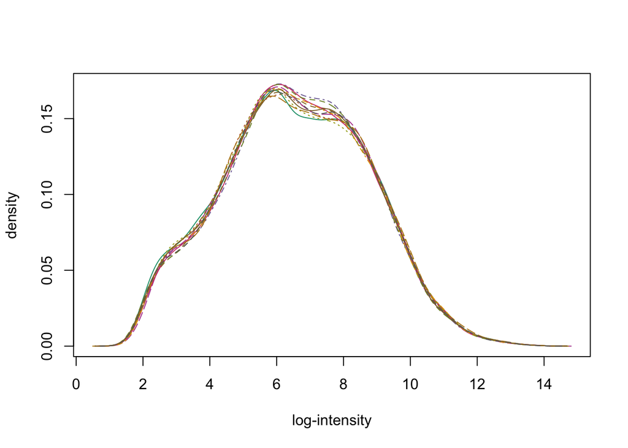

```r
hist(data.rma.norm) # histogram of normalized data
```

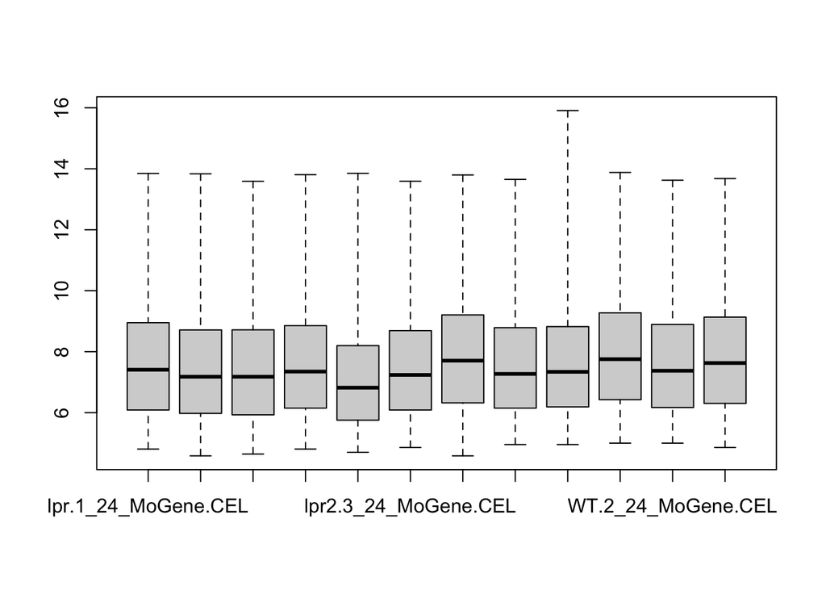

```r
#image(rawData)# takes some time to load images.
boxplot(rawData)
```

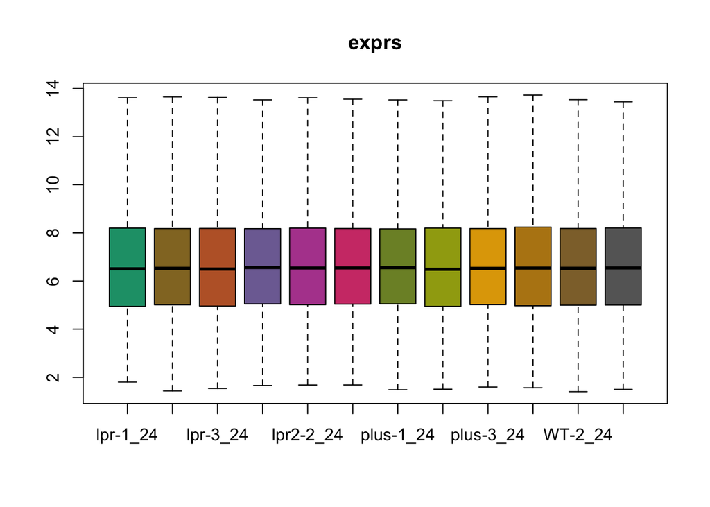

```r
boxplot(data.rma.norm) # boxplot of normalized data
```

## Annotation

```r
# Get the annotation data for the normalized data object
data.rma.norm@annotation
```

```
## [1] "mogene10stv1"
```

```r
# Extract the expression values from the normalized data object
rma <- exprs(data.rma.norm)

# Get the probe names from the normalized data object
probes <- featureNames(data.rma.norm)

# Get the mogene10sttranscriptcluster database
x <- mogene10sttranscriptcluster.db

# Get the Symbol, Name, Entrez ID, and GO term for each probe
Symbol = unlist(mget(probes, mogene10sttranscriptclusterSYMBOL, ifnotfound=NA))
Name =  unlist(mget(probes, mogene10sttranscriptclusterGENENAME, ifnotfound=NA))
Entrez_IDs = unlist(mget(probes, mogene10sttranscriptclusterENTREZID, ifnotfound=NA))
GO = unlist(mget(probes, mogene10sttranscriptclusterGO, ifnotfound=NA))

# Bind the probe names, symbols, names, entrez IDs, GO terms, and expression values together
annotated <- cbind(probes, Symbol, Name, Entrez_IDs, GO, rma)
# Create a data frame with the probe ID, symbol, name, and entrez ID, replacing NA values with actual NA
tmp <- data.frame(ID=probes, Symbol=Symbol, Name=Name, Entrez_IDs, stringsAsFactors=F)
tmp[tmp=="NA"] <- NA

# Set the annotation data of the normalized data object to the new data frame
fData(data.rma.norm) <- tmp

# Write the annotated data to a file
write.table(annotated, file = "annotation.txt", quote = FALSE, sep = "\t", row.names = FALSE, col.names = TRUE)
```

The code below removes probesets with No Names. However, we didn’t want to remove them this early in the analysis.

```r
# #remove probe sets with No Names
# HasSymbol <- !is.na(fData(data.rma.norm)$Symbol)
# data.rma.norm <- data.rma.norm[HasSymbol,]
# head(fData(data.rma.norm))
# dim(data.rma.norm)
# fData(data.rma.norm)$Symbol
```

## LIMMA differential analysis groups

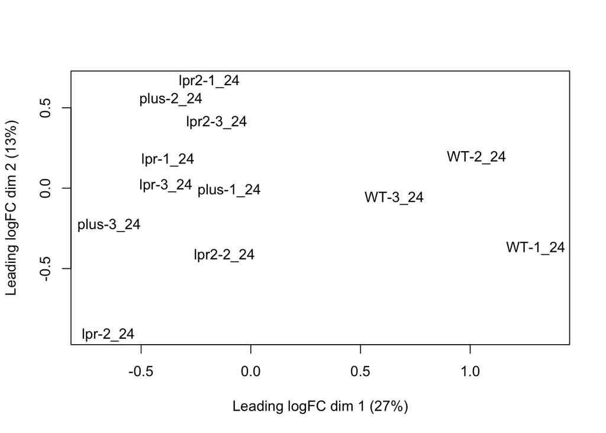

```r
plotMDS(data.rma.norm) #checking batch effect
```

following: https://www.bioconductor.org/packages/devel/bioc/vignettes/limma/inst/doc/usersguide.pdf @ Page 102 model matrices: https://www.montana.edu/rotella/documents/502/DesignMatricesR.pdf

```r
#Differential expression
Exp <- factor(targets24$Experiment, levels = c ("24"))
Strain <- factor(targets24$Strain, levels=c("lpr","lpr2","plus","WT"))
design<- model.matrix(~0 + Strain )
design
```

```
##    Strainlpr Strainlpr2 Strainplus StrainWT
## 1          1          0          0        0
## 2          1          0          0        0
## 3          1          0          0        0
## 4          0          1          0        0
## 5          0          1          0        0
## 6          0          1          0        0
## 7          0          0          1        0
## 8          0          0          1        0
## 9          0          0          1        0
## 10         0          0          0        1
## 11         0          0          0        1
## 12         0          0          0        1
## attr(,"assign")
## [1] 1 1 1 1
## attr(,"contrasts")
## attr(,"contrasts")$Strain
## [1] "contr.treatment"
```

[output not shown]

The summary of the results are as follows:

```r
summary(results)
```

```
##        Strainlpr-Strainlpr2 Strainlpr-Strainplus Strainlpr-StrainWT
## Down                      1                    1                268
## NotSig                34758                34756              34287
## Up                        1                    3                205
##        Strainlpr2-Strainplus Strainlpr2-StrainWT Strainplus-StrainWT
## Down                       2                 165                 160
## NotSig                 34755               34510               34505
## Up                         3                  85                  95
```

## Extracting differentially expressed genes

The topTable function can be used to extract genes with the preferred cutoff criterea.

```r
genesT24lpr2_wt<- topTable(data.fit.eb, coef="Strainlpr2-StrainWT", n=Inf, lfc = 1.5)
genesT24lpr_lpr2<- topTable(data.fit.eb, coef="Strainlpr-Strainlpr2", n=Inf, lfc = 1.5)
genesT24lpr_plus<- topTable(data.fit.eb, coef="Strainlpr-Strainplus", n=Inf, lfc = 1.5)
genesT24lpr_WT<- topTable(data.fit.eb, coef="Strainlpr-StrainWT", n=Inf, lfc = 1.5)
genesT24lpr2_plus<- topTable(data.fit.eb, coef="Strainlpr2-Strainplus", n=Inf, lfc = 1.5)
genesT24plus_WT<- topTable(data.fit.eb, coef="Strainplus-StrainWT", n=Inf, lfc = 1.5)
```

# T18

## Quick visualizations

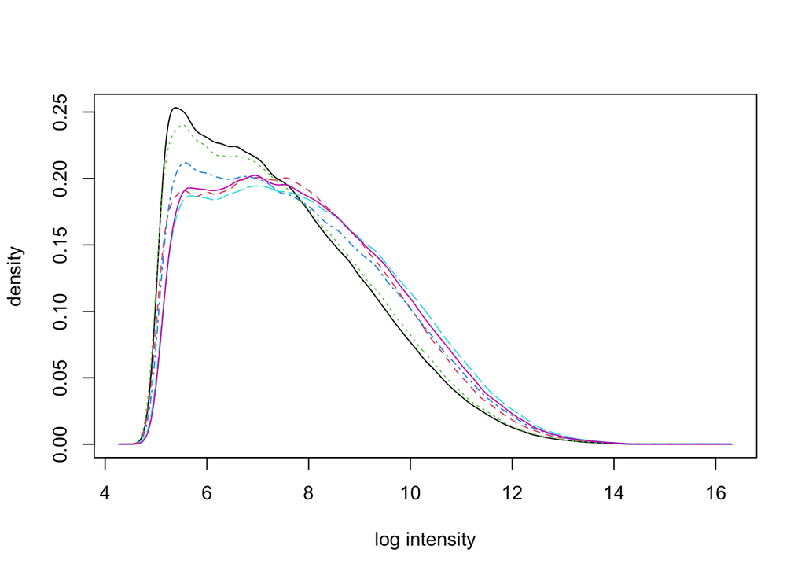

```r
hist(rawDataT18) # quick hist summary of log_difference
```

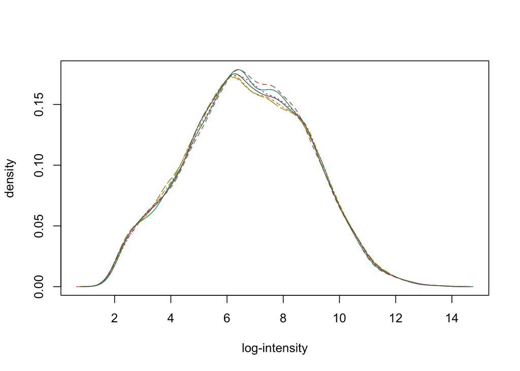

```r
hist(data.rma.normT18)
```

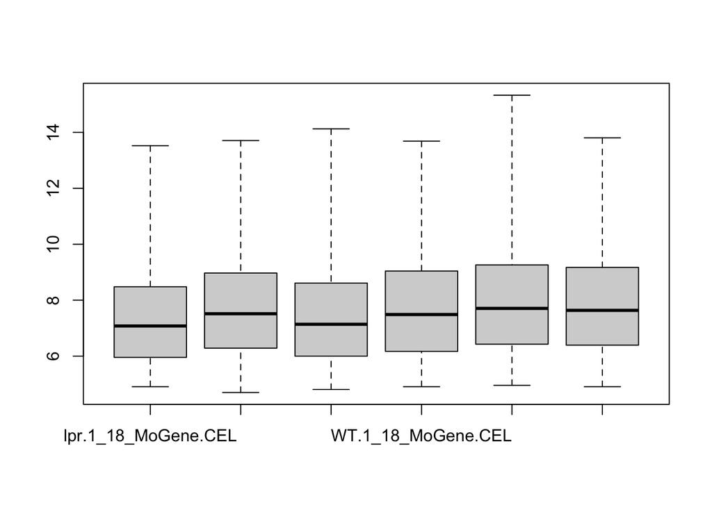

```r
#image(rawData)# takes a bit of time loads images
boxplot(rawDataT18)
```

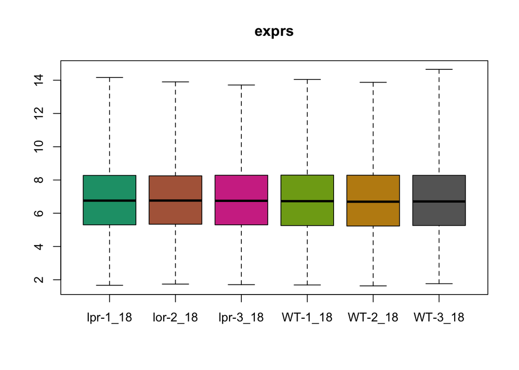

```r
boxplot(data.rma.normT18)
```